[figure not shown]

# Literature

### Total Articles

307

### Unique Authors

748

### Years Covered

1935–2025

### Insecticides & Pesticides

5 articles

### Insect Anesthetics

2 articles

### Farming & Agriculture

51 articles

### Top 15 Most Frequent Topics

[interactive chart not shown]

### Word Cloud of Article Titles

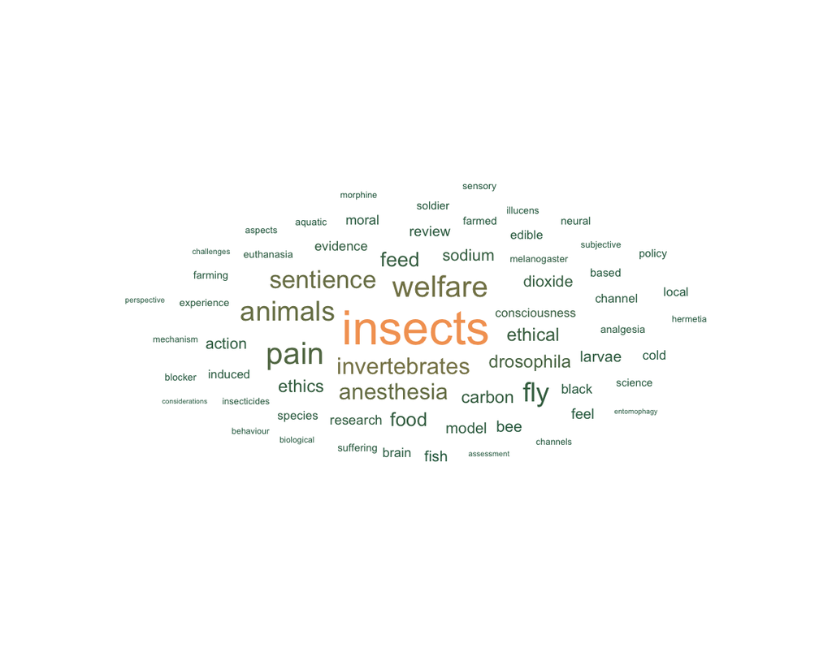

### Evolution of Publications per Year

[interactive chart not shown]

### Article Types Over Time

[interactive chart not shown]

### Spotlight: Key Research Areas Over Time

[interactive chart not shown]

### Evolution of Top 5 Research Topics

[interactive chart not shown]

### Most Prolific Authors

[interactive chart not shown]

### Researcher Co-authorship Network

[interactive chart not shown]

### Topic Co-occurrence Network

[interactive chart not shown]

📍 Research Landscape — Where is the field concentrating, and where are the gaps?

### Welfare Criteria Coverage

[interactive chart not shown]

### Study Design Balance

[interactive chart not shown]

📚 Data source: [IWRS Research Library](https://www.insectwelfare.com/research-library) — Insect Welfare Research Society 💻 Dashboard: **Solimary García-Hernández** · solimarygarcia@gmail.com · *Built with AI assistance (Claude Code · Anthropic)*

# Community

### Total Members

184

### Countries Represented

49

### Disciplines

117

### Global Member Map

[interactive chart not shown]

### Members by Country (Top 20)

[interactive chart not shown]

### Members by Discipline

[interactive chart not shown]

### Members by Rank

[interactive chart not shown]

📚 Data source: [IWRS Research Library](https://www.insectwelfare.com/research-library) — Insect Welfare Research Society 💻 Dashboard: **Solimary García-Hernández** · solimarygarcia@gmail.com · *Built with AI assistance (Claude Code · Anthropic)*

# Fairer Fields

**Fairer Fields** — Articles from the library related to insecticides & pesticides, insect anesthetics, killing methods, and farming & agriculture. Use the search box and column filters to explore. Future feature: click any row to get an AI-generated summary.

### Literature on Key Research Areas

| Title | Authors | Year | Areas | Topics | DOI |
| --- | --- | --- | --- | --- | --- |
| Entomophagy: What, If Anything, Do We Owe to Insects? | Martin, Angela K. |  | Farming & Agriculture | Book Chapter · Farming · Food/feed · Moral Status · Sentience | — |
| Insect Pain and Suffering by Humans: An Argument for Misanthropic Anti-natalism | Smith, Oliver D. | 2022 | Anesthetics / Killing Methods | Theoretical Primary · Killing Method · Pain | 🔗 Open |
| Welfare of farmed insects | van Huis, A. | 2019 | Farming & Agriculture | Opinion · Behavior · Farming · Food/feed · Moral Status · Pain · Sentience · Welfare | 🔗 Open |
| Eating insects and tourism: Ethical challenges in a changing world | Perdue, Robert Todd | 2018 | Farming & Agriculture | Book Chapter · Farming · Food/feed | — |
| Considering animals’ feelings: Précis of Sentience and animal welfare (Broom 2014) | Broom, Donald | 2016 | Anesthetics / Killing Methods | Opinion · Fish · Invertebrate · Killing Method · Moral Status · Sentience · Welfare | 🔗 Open |
| Perspective: Opportunities for advancing aquatic invertebrate welfare | Wahltinez, Sarah J.; Stacy, Nicole I.; Hadfield, Catherine A.; Harms, Craig A.; Lewbart, Gregory A.; Newton, Alisa L.; Nunamaker, Elizabeth A. | 2022 | Anesthetics / Killing Methods | Perspective · Cephalopod · Decapod · Invertebrate · Killing Method · Welfare | 🔗 Open |
| Farmed Yellow Mealworm (Tenebrio molitor; Coleoptera: Tenebrionidae) Welfare: Species-Specific Recommendations for a Global Industry | Barrett, Meghan; Godfrey, Rebekah Keating; Schnell, Alexandra; Fischer, Bob | 2023 | Anesthetics / Killing Methods | Review · Beetle · Farming · Juvenile · Killing Method · Rearing | 🔗 Open |
| Evaluation of Targeted Injections of Ivermectin or Potassium Chloride for Euthanasia of Anesthetized Thorny Devil Stick Insects (Eurycantha calcarata) | Heniff, Ashlyn C.; Gorges, Melinda A.; Lewbart, Gregory A.; Balko, Julie A. | 2023 | Anesthetics / Killing Methods | Empirical Primary · Killing Method · Phasmid | 🔗 Open |
| Chapter 26: Anesthesia and analgesia in invertebrates | Wahltinez, Sarah J.; Harms, Craig A.; Lewbart, Gregory A. | 2023 | Anesthetics / Killing Methods | Anaesthetic · Analgesic · Book Chapter · Killing Method · Pain | — |
| AVMA Guidelines for the Euthanasia of Animals: 2020 Edition | Leary, Steven; Pharmaceuticals, Fidelis; Underwood, Wendy; Anthony, Raymond; Cartner, Samuel; Johnson, Cia L; Patterson-Kane, Emily | 2020 | Anesthetics / Killing Methods | Protocol · Killing Method | — |

[output cut: 62 more lines]

✨ **AI Summary Preview** — demonstration of a future feature. In the full version, each article will have an automatically generated structured summary.

### AI-Generated Summary (Demo)

AI SUMMARY · DEMO Insecticides

Indoxacarb, an oxadiazine insecticide, blocks insect neuronal sodium channels

Lapied et al. · *British Journal of Pharmacology* · 2001

🔬 Hypothesis

DCJW (active metabolite of indoxacarb) selectively blocks voltage-dependent Na⁺ channels in insect neurons via a binding site shared with local anesthetics, distinct from pyrethroids and TTX.

⚗️ Experiments

Whole-cell patch-clamp on isolated cockroach (*Periplaneta americana*) DUM neurons; IC50 dose-response curves; co-application with TTX and lidocaine; Ca²⁺/K⁺ selectivity tests.

📊 Results

IC50 = 28 nM; additive with TTX; competitive with lidocaine; no effect on Ca²⁺ or K⁺; membrane hyperpolarized from −53.5 to −72.5 mV.

**🔬 Want to know more about the methodology?**

- DUM (*dorsal unpaired median*) neurons enzymatically isolated from the terminal abdominal ganglia of *Periplaneta americana*.
- **Whole-cell patch-clamp** in a superfusion chamber (~0.1 mL volume) at room temperature.
- DCJW applied via bath superfusion at concentrations ranging 1 nM to 10 µM; TTX used at 300 nM as a reference sodium channel blocker.
- Lidocaine tested at 1–30 mM for competitive co-application experiments.
- Ca²⁺ currents measured using Ba²⁺ as charge carrier; K⁺ currents isolated in Ca²⁺-free external solution.
- Membrane potential recorded in current-clamp mode; input resistance calculated from responses to hyperpolarizing current pulses.

**⚗️ Want to know more about the statistical analyses?**

- Concentration-response curves fitted with the **Hill equation** to derive IC50 and Hill coefficient.
- Current amplitudes normalized to pre-drug control peak values.
- DCJW + TTX combined inhibition analysed to test **additivity vs. independence** of binding sites.
- DCJW + lidocaine co-application tested for **competitive interaction**: combined effect significantly lower than additive expectation confirms shared binding site.
- Statistical comparisons by **paired t-test** (currents before vs. during drug application); p < 0.05.
- Input resistance and resting membrane potential compared before and during DCJW superfusion.

**📊 Want to know more about the main results?**

- **IC50 = 28 nM** for peak sodium current inhibition — 10× less potent than TTX, but ~1,000× more potent than lidocaine.
- DCJW + TTX combination produced **additive inhibition**, confirming they act at independent, non-overlapping binding sites.
- DCJW + lidocaine produced **less-than-additive inhibition**, confirming competitive binding at a shared site (local anesthetic receptor).
- No significant effect on Ca²⁺ or K⁺ currents at tested concentrations — **high selectivity for Na⁺ channels**.
- Resting membrane potential shifted from −53.5 mV to −72.5 mV (hyperpolarization); **input resistance increased by ~41%**.
- First mechanistic characterisation of indoxacarb action on insect neuronal sodium channels, providing a pharmacological basis distinct from all prior insecticide classes.

**💡 Open questions & future directions**

- Does DCJW affect other insect sodium channel subtypes (e.g., para-type variants expressed in sensory neurons)?
- Is the lidocaine-shared binding site conserved across beneficial insects — particularly bees (*Apis mellifera*) and other pollinators?
- What are the **sublethal behavioural consequences** of DCJW at environmentally relevant concentrations (below IC50)?
- Could this pharmacological target be exploited to design **more selective** insecticides with reduced off-target effects?
- How does resistance to indoxacarb evolve at the molecular level — are sodium channel mutations observed in resistant field populations?

AI SUMMARY · DEMO Anesthetics · Insecticides

Convergent evolution of *Rdl* duplications as insect counter-defense against plant neurotoxins and synthetic insecticides

Guo et al. · *Nature Ecology & Evolution* · 2023

🔬 Hypothesis

Convergent amino acid substitutions in duplicated *Rdl* (GABA receptor gene) evolved over 300 Myr as a counter-defense against plant terpenoids — and the same changes rapidly re-emerged against synthetic insecticides.

⚗️ Experiments

Phylogenetics (22 orders, 171 families); molecular docking; CRISPR-Cas9 in *Drosophila*; survival bioassays on picrotoxin/thymol; fitness cost assays; ancestral-state reconstruction.

📊 Results

≥8 independent *Rdl* duplications; 2′ substitutions sterically block NCA binding; *Rdl* copy number explains 10–14% of diversification variance in Lepidoptera.

**🔬 Want to know more about the methodology?**

- Maximum-likelihood phylogenetic reconstruction across 411 species (22 insect orders, 171 families); *Rdl* gene copy number counted per genome.
- Homology models of the RDL receptor based on the *C. elegans* GluCl crystal structure; **molecular docking** with AutoDock Vina for picrotoxin and thymol.
- **CRISPR-Cas9** editing in *Drosophila melanogaster* (w¹¹¹⁸ background): introduced substitutions A2'S, A2'Q, A2'N, A2'P and T6'I at the 2' pore-lining position.
- Survival bioassays: picrotoxin- and thymol-supplemented diets at increasing concentrations, tested in adults and larvae.
- Fitness cost assays: egg-laying rate, heat-induced paralysis (37 °C), and locomotor performance (climbing assay) across genotypes.

**⚗️ Want to know more about the statistical analyses?**

- **Ancestral-state reconstruction** via stochastic character mapping to infer the origin of duplications and substitutions across the phylogeny.
- Sister-clade **diversification rate comparison** (BiSSE-like approach); Pearson correlation between *Rdl* copy number and net diversification rate.
- Docking scores compared between wild-type and mutant receptor models to quantify **binding affinity reduction** for picrotoxin/thymol.
- Survival analysed with **logistic regression**; S/S and Q/+ genotypes compared against controls.
- Fitness costs tested with **Mann-Whitney U tests**; Q/Q and P/P genotypes showed significantly reduced fecundity and increased heat-induced paralysis.

**📊 Want to know more about the main results?**

- Identified **≥8 independent *Rdl* gene duplication events** across insect lineages, distributed across Lepidoptera, Diptera, Coleoptera, and others.
- Substitutions at the **2′ pore-lining position** (A2'S, A2'Q) reduce pore radius, sterically blocking the binding of non-competitive antagonists (picrotoxin, thymol, fipronil).
- S/S and Q/+ genotypes showed **significantly increased survival** on both picrotoxin and thymol diets; P/P genotype was less effective.
- *Rdl* copy number **positively correlates with net diversification rate** in Lepidoptera, explaining 10–14% of variance — suggesting a macroevolutionary advantage.
- **Fitness trade-offs**: Q/Q homozygotes showed reduced egg-laying and higher heat-induced paralysis, suggesting the duplicate copy buffers fitness costs in heterozygotes.
- The same 2′ substitutions documented in **field-collected resistant populations** within one human lifetime — evolutionary parallel between deep evolutionary history and contemporary insecticide resistance.

**💡 Open questions & future directions**

- Do *Rdl* duplications provide resistance to **other GABA-targeting insecticides** (e.g., dieldrin, endosulfan) beyond fipronil and picrotoxin?
- Do similar convergent mechanisms occur in **other receptor families** (sodium channels, acetylcholinesterase) under plant-derived toxin pressure?
- Can *Rdl* copy number variation be used to **predict resistance evolution** in uncharacterised pest species before it emerges?
- How do *Rdl* duplications affect **ecologically relevant interactions** — e.g., competition, predator-prey dynamics in naturally terpenoid-rich environments?
- What are the **welfare implications** for insects whose GABA receptors are structurally altered — does insecticide action cause different pain/distress responses in resistant vs. susceptible individuals?

📚 Data source: [IWRS Research Library](https://www.insectwelfare.com/research-library) — Insect Welfare Research Society 💻 Dashboard: **Solimary García-Hernández** · solimarygarcia@gmail.com · *Built with AI assistance (Claude Code · Anthropic)*

# Cost-Effectiveness

### Paying Farmers for Humane Pesticides — Interactive Simulator

🌾 Welfare Cost-Effectiveness Simulator

How many insect death-experiences are prevented per dollar spent compensating farmers to switch to a more humane pesticide?

**▶ 💡 What is this? & How it works**

**What is this?**  
This interactive simulator estimates the cost-effectiveness of paying farmers to switch from a conventional pesticide to a more humane alternative — one that kills insects faster, reducing the total duration of suffering.

**How it works**  
The model computes **R**, the expected number of insect death-experiences prevented per dollar spent on farmer compensation. R is driven by five parameters you control:

- **p** — how likely you think insects can feel pain
- **n** — how many insects live on a hectare of cropland
- **f** — what fraction of those insects are killed by pesticide application
- **s** — how much less painful the humane pesticide is relative to the current one
- **c** — the extra cost per hectare of using the humane pesticide

The **"What does this mean in practice?"** section translates the result into plain farmer-scale numbers: how many insects are spared on a farm of your chosen size, what the subsidy would cost per season, and how much it costs to prevent 1,000 insects from unnecessary suffering.

**Why does it matter?** Even under conservative assumptions, the cost per unit of suffering prevented is remarkably low — suggesting that farmer subsidy programs targeting pesticide humaneness could be among the most cost-effective interventions in insect welfare.

📐 Set Your Parameters

*p* — Probability insects feel pain 0.100

Your subjective belief that insects are sentient and capable of experiencing suffering. Likely varies by species; treated here as a single value across all insects.

0.001 (very unlikely)0.6 (quite likely)

*n* — Insects per hectare 3.3M

Average number of insects (and other small sentient organisms) inhabiting one hectare of cropland during the growing season. Varies widely by crop type and region.

163K65M

*f* — Fraction killed by pesticide 0.80

Proportion of insects on a treated hectare that are killed or significantly harmed by a single pesticide application. Assumes both pesticides are equally potent.

0.05 (few affected)1.0 (all killed)

*s* — Painfulness ratio (humane / harmful) 0.50 (50% reduction)

How painful the humane pesticide is relative to the current one, per unit of time. E.g., s = 0.5 means the humane pesticide kills twice as fast, causing half the total suffering. Lower = greater welfare benefit.

0.05 (95% less painful)0.99 (1% less painful)

*c* — Cost premium per hectare ($) $4.50

The extra cost per hectare of using the more humane pesticide instead of the current one. This is the amount a subsidy program would need to compensate farmers per hectare treated.

$1$300

🌾 What does this mean in practice?

Farm size: hectares

Given the uncertainty in these parameters, results can vary enormously — where do your assumptions land?

📖 How to read this chart

The x-axis shows **R** — the expected number of insect death-experiences prevented per dollar — on a **logarithmic scale** (powers of 10). Because the inputs are uncertain and span many orders of magnitude, the result can range from tens to hundreds of millions; a log scale makes the full distribution visible at once.

The **green bars** are a Monte Carlo distribution: 50,000 simulations drawn randomly from the uncertainty ranges described in the original model (Brian Tomasik). Each bar shows how often R fell in that range — a tall bar means that outcome is more probable under those priors. Bars to the *left* of your red line are shaded lighter to help you see where your estimate sits relative to the distribution.

The red vertical line is **your point estimate** — the single value of R computed directly from your slider settings. If it falls near the center of the distribution, your assumptions are typical. If it falls in the tail, your assumptions are more optimistic or pessimistic than the model average.

The orange dashed line is the **Monte Carlo mean** — the average R across all 50,000 simulations using the original priors. Compare it to your red line to see how your assumptions differ from the model defaults.

**If your red line is to the right of the orange:** your assumptions are more optimistic than the model average — you believe the intervention prevents more suffering per dollar (e.g., you assigned a higher probability that insects feel pain, or assumed a larger insect population).  
**If your red line is to the left of the orange:** your assumptions are more conservative — you expect fewer insects to benefit, or the cost premium is too high to make the intervention efficient under your values.

Expected R (point est.)

death-exp. prevented / $

Suffering reduction

vs. current pesticide

📄 **Based on:** [Humane Insecticides](https://reducing-suffering.org/humane-insecticides/) — Brian Tomasik, *Essays on Reducing Suffering*. Last updated: November 12, 2018.

💻 **Dashboard implementation:** Solimary García-Hernández, for the *Fairer Fields* initiative · solimarygarcia@gmail.com

**⚠️ Model ignores:** fixed research costs · administrative overhead · farmer outreach · compliance monitoring. MC priors: ln(*p*) ~ U[−6, −0.5] · ln(*n*) ~ N(15, 2) · *f* ~ N(0.8, 0.05) · *s* ~ U[0.3, 0.9] · *c* ~ U[$1, $8].